# Optimal Treatment Analysis

## Outcome Variable

**Outcome Variable:** whz

## Predictor Variables

**Intervention Variable:** perdiar6

**Adjustment Set:**

- arm
- sex
- W_mage
- meducyrs
- feducyrs
- hhwealth_quart
- hfoodsec
- W_mhtcm
- W_mwtkg
- W_mbmi
- W_birthwt
- W_birthlen
- W_nrooms
- month
- brthmon
- impfloor
- impsan
- safeh20
- delta_W_mage
- delta_meducyrs
- delta_feducyrs
- delta_hhwealth_quart
- delta_hfoodsec
- delta_W_mhtcm
- delta_W_mwtkg
- delta_W_mbmi
- delta_W_birthwt
- delta_W_birthlen
- delta_W_nrooms
- delta_month
- delta_brthmon
- delta_impfloor
- delta_impsan
- delta_safeh20

## Stratifying Variables

The analysis was stratified on these variable(s):

- agecat
- studyid
- country

## Data Summary

| agecat | studyid | country | perdiar6 | n_cell | n |
| --- | --- | --- | --- | --- | --- |
| Birth | ki0047075b-MAL-ED | BANGLADESH | 0% | 65 | 215 |
| Birth | ki0047075b-MAL-ED | BANGLADESH | (0%, 5%] | 86 | 215 |
| Birth | ki0047075b-MAL-ED | BANGLADESH | >5% | 64 | 215 |
| Birth | ki0047075b-MAL-ED | BRAZIL | 0% | 54 | 62 |
| Birth | ki0047075b-MAL-ED | BRAZIL | (0%, 5%] | 6 | 62 |
| Birth | ki0047075b-MAL-ED | BRAZIL | >5% | 2 | 62 |
| Birth | ki0047075b-MAL-ED | INDIA | 0% | 11 | 45 |
| Birth | ki0047075b-MAL-ED | INDIA | (0%, 5%] | 23 | 45 |
| Birth | ki0047075b-MAL-ED | INDIA | >5% | 11 | 45 |
| Birth | ki0047075b-MAL-ED | NEPAL | 0% | 8 | 26 |
| Birth | ki0047075b-MAL-ED | NEPAL | (0%, 5%] | 10 | 26 |
| Birth | ki0047075b-MAL-ED | NEPAL | >5% | 8 | 26 |
| Birth | ki0047075b-MAL-ED | PERU | 0% | 67 | 228 |
| Birth | ki0047075b-MAL-ED | PERU | (0%, 5%] | 69 | 228 |
| Birth | ki0047075b-MAL-ED | PERU | >5% | 92 | 228 |
| Birth | ki0047075b-MAL-ED | SOUTH AFRICA | 0% | 85 | 112 |
| Birth | ki0047075b-MAL-ED | SOUTH AFRICA | (0%, 5%] | 23 | 112 |
| Birth | ki0047075b-MAL-ED | SOUTH AFRICA | >5% | 4 | 112 |
| Birth | ki0047075b-MAL-ED | TANZANIA, UNITED REPUBLIC OF | 0% | 51 | 115 |
| Birth | ki0047075b-MAL-ED | TANZANIA, UNITED REPUBLIC OF | (0%, 5%] | 44 | 115 |
| Birth | ki0047075b-MAL-ED | TANZANIA, UNITED REPUBLIC OF | >5% | 20 | 115 |
| Birth | ki1000109-EE | PAKISTAN | 0% | 164 | 177 |
| Birth | ki1000109-EE | PAKISTAN | (0%, 5%] | 11 | 177 |
| Birth | ki1000109-EE | PAKISTAN | >5% | 2 | 177 |
| Birth | ki1017093-NIH-Birth | BANGLADESH | 0% | 150 | 572 |
| Birth | ki1017093-NIH-Birth | BANGLADESH | (0%, 5%] | 171 | 572 |
| Birth | ki1017093-NIH-Birth | BANGLADESH | >5% | 251 | 572 |
| Birth | ki1017093b-PROVIDE | BANGLADESH | 0% | 160 | 532 |
| Birth | ki1017093b-PROVIDE | BANGLADESH | (0%, 5%] | 206 | 532 |
| Birth | ki1017093b-PROVIDE | BANGLADESH | >5% | 166 | 532 |

[output cut: 87 more lines]

The following strata were considered:

- agecat: 24 months, studyid: ki0047075b-MAL-ED, country: BANGLADESH
- agecat: 24 months, studyid: ki0047075b-MAL-ED, country: BRAZIL
- agecat: 24 months, studyid: ki0047075b-MAL-ED, country: INDIA
- agecat: 24 months, studyid: ki0047075b-MAL-ED, country: NEPAL
- agecat: 24 months, studyid: ki0047075b-MAL-ED, country: PERU
- agecat: 24 months, studyid: ki0047075b-MAL-ED, country: SOUTH AFRICA
- agecat: 24 months, studyid: ki0047075b-MAL-ED, country: TANZANIA, UNITED REPUBLIC OF
- agecat: 24 months, studyid: ki1000109-EE, country: PAKISTAN
- agecat: 24 months, studyid: ki1017093-NIH-Birth, country: BANGLADESH
- agecat: 24 months, studyid: ki1017093b-PROVIDE, country: BANGLADESH
- agecat: 24 months, studyid: ki1017093c-NIH-Crypto, country: BANGLADESH
- agecat: 24 months, studyid: ki1114097-CMIN, country: BANGLADESH
- agecat: 24 months, studyid: ki1114097-CONTENT, country: PERU
- agecat: 6 months, studyid: ki0047075b-MAL-ED, country: BANGLADESH
- agecat: 6 months, studyid: ki0047075b-MAL-ED, country: BRAZIL
- agecat: 6 months, studyid: ki0047075b-MAL-ED, country: INDIA
- agecat: 6 months, studyid: ki0047075b-MAL-ED, country: NEPAL
- agecat: 6 months, studyid: ki0047075b-MAL-ED, country: PERU
- agecat: 6 months, studyid: ki0047075b-MAL-ED, country: SOUTH AFRICA
- agecat: 6 months, studyid: ki0047075b-MAL-ED, country: TANZANIA, UNITED REPUBLIC OF
- agecat: 6 months, studyid: ki1000109-EE, country: PAKISTAN
- agecat: 6 months, studyid: ki1017093-NIH-Birth, country: BANGLADESH
- agecat: 6 months, studyid: ki1017093b-PROVIDE, country: BANGLADESH
- agecat: 6 months, studyid: ki1017093c-NIH-Crypto, country: BANGLADESH
- agecat: 6 months, studyid: ki1114097-CMIN, country: BANGLADESH
- agecat: 6 months, studyid: ki1114097-CONTENT, country: PERU
- agecat: Birth, studyid: ki0047075b-MAL-ED, country: BANGLADESH
- agecat: Birth, studyid: ki0047075b-MAL-ED, country: BRAZIL
- agecat: Birth, studyid: ki0047075b-MAL-ED, country: INDIA
- agecat: Birth, studyid: ki0047075b-MAL-ED, country: NEPAL
- agecat: Birth, studyid: ki0047075b-MAL-ED, country: PERU
- agecat: Birth, studyid: ki0047075b-MAL-ED, country: SOUTH AFRICA
- agecat: Birth, studyid: ki0047075b-MAL-ED, country: TANZANIA, UNITED REPUBLIC OF
- agecat: Birth, studyid: ki1000109-EE, country: PAKISTAN
- agecat: Birth, studyid: ki1017093-NIH-Birth, country: BANGLADESH
- agecat: Birth, studyid: ki1017093b-PROVIDE, country: BANGLADESH
- agecat: Birth, studyid: ki1017093c-NIH-Crypto, country: BANGLADESH
- agecat: Birth, studyid: ki1114097-CMIN, country: BANGLADESH
- agecat: Birth, studyid: ki1114097-CONTENT, country: PERU

### Dropped Strata

Some strata were dropped due to rare outcomes:

- agecat: Birth, studyid: ki0047075b-MAL-ED, country: BRAZIL
- agecat: Birth, studyid: ki0047075b-MAL-ED, country: SOUTH AFRICA
- agecat: Birth, studyid: ki1000109-EE, country: PAKISTAN
- agecat: Birth, studyid: ki1114097-CMIN, country: BANGLADESH
- agecat: Birth, studyid: ki1114097-CONTENT, country: PERU
- agecat: 6 months, studyid: ki0047075b-MAL-ED, country: BRAZIL
- agecat: 6 months, studyid: ki1000109-EE, country: PAKISTAN
- agecat: 24 months, studyid: ki0047075b-MAL-ED, country: BRAZIL
- agecat: 24 months, studyid: ki1000109-EE, country: PAKISTAN

## Methods Detail

We’re interested in the causal parameters $E[Y_a]$ for all values of $a \in \mathcal{A}$. These parameters represent the mean outcome if, possibly contrary to fact, we intervened to set all units to have $A=a$. Under the randomization and positivity assumptions, these are identified by the statistical parameters $\psi_a=E_W[E_{Y|A,W}(Y|A=a,W)]$. In addition, we’re interested in the mean of $Y$, $E[Y]$ under no intervention (the observed mean). We will estimate these parameters by using SuperLearner to fit the relevant likelihood factors – $E_{Y|A,W}(Y|A=a,W)$ and $p(A=a|W)$, and then updating our likelihood fit using a joint TMLE.

For unadjusted analyses ($W=\{\}$), initial likelihoods were estimated using Lrnr_glm to estimate the simple $E(Y|A)$ and Lrnr_mean to estimate $p(A)$. For adjusted analyses, a small library containing Lrnr_glmnet, Lrnr_xgboost, and Lrnr_mean was used.

Having estimated these parameters, we will then use the delta method to estimate relative risks and attributable risks relative to a prespecified baseline level of $A$.

# Results Detail

## Results Plots

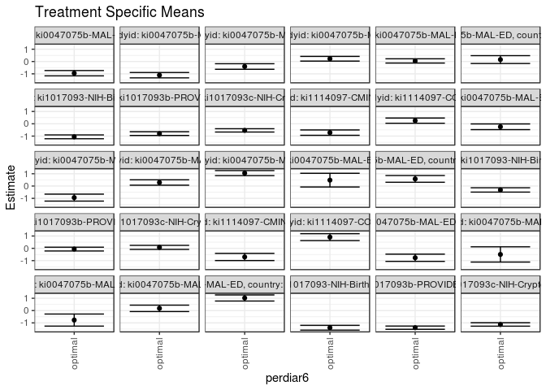

## Results Table

### Parameter: TSM

| agecat | studyid | country | intervention_level | baseline_level | estimate | ci_lower | ci_upper |
| --- | --- | --- | --- | --- | --- | --- | --- |
| Birth | ki0047075b-MAL-ED | BANGLADESH | optimal | observed | -0.7671070 | -1.0599470 | -0.4742671 |
| Birth | ki0047075b-MAL-ED | INDIA | optimal | observed | -0.4973100 | -1.1157381 | 0.1211181 |
| Birth | ki0047075b-MAL-ED | NEPAL | optimal | observed | -0.7711171 | -1.2605647 | -0.2816695 |
| Birth | ki0047075b-MAL-ED | PERU | optimal | observed | 0.1823753 | -0.0774332 | 0.4421838 |
| Birth | ki0047075b-MAL-ED | TANZANIA, UNITED REPUBLIC OF | optimal | observed | 1.0232672 | 0.7760669 | 1.2704676 |
| Birth | ki1017093-NIH-Birth | BANGLADESH | optimal | observed | -1.3925036 | -1.5871626 | -1.1978446 |
| Birth | ki1017093b-PROVIDE | BANGLADESH | optimal | observed | -1.3875967 | -1.5192424 | -1.2559511 |
| Birth | ki1017093c-NIH-Crypto | BANGLADESH | optimal | observed | -1.1288310 | -1.2661854 | -0.9914766 |
| 6 months | ki0047075b-MAL-ED | BANGLADESH | optimal | observed | -0.2427241 | -0.4731023 | -0.0123460 |
| 6 months | ki0047075b-MAL-ED | INDIA | optimal | observed | -0.9392225 | -1.2218955 | -0.6565496 |
| 6 months | ki0047075b-MAL-ED | NEPAL | optimal | observed | 0.2884022 | 0.0687344 | 0.5080699 |
| 6 months | ki0047075b-MAL-ED | PERU | optimal | observed | 1.0503268 | 0.8467247 | 1.2539289 |
| 6 months | ki0047075b-MAL-ED | SOUTH AFRICA | optimal | observed | 0.4805800 | -0.0760197 | 1.0371796 |
| 6 months | ki0047075b-MAL-ED | TANZANIA, UNITED REPUBLIC OF | optimal | observed | 0.5812464 | 0.3077051 | 0.8547877 |
| 6 months | ki1017093-NIH-Birth | BANGLADESH | optimal | observed | -0.3154041 | -0.4903742 | -0.1404340 |
| 6 months | ki1017093b-PROVIDE | BANGLADESH | optimal | observed | -0.0620721 | -0.2156347 | 0.0914906 |
| 6 months | ki1017093c-NIH-Crypto | BANGLADESH | optimal | observed | 0.0762858 | -0.0876202 | 0.2401918 |
| 6 months | ki1114097-CMIN | BANGLADESH | optimal | observed | -0.7023438 | -0.9927515 | -0.4119361 |
| 6 months | ki1114097-CONTENT | PERU | optimal | observed | 0.9088797 | 0.6287640 | 1.1889955 |
| 24 months | ki0047075b-MAL-ED | BANGLADESH | optimal | observed | -0.9492462 | -1.1640393 | -0.7344531 |
| 24 months | ki0047075b-MAL-ED | INDIA | optimal | observed | -1.1089601 | -1.3262944 | -0.8916257 |
| 24 months | ki0047075b-MAL-ED | NEPAL | optimal | observed | -0.4044489 | -0.6301972 | -0.1787005 |
| 24 months | ki0047075b-MAL-ED | PERU | optimal | observed | 0.2261474 | 0.0346850 | 0.4176099 |
| 24 months | ki0047075b-MAL-ED | SOUTH AFRICA | optimal | observed | 0.0481986 | -0.1245607 | 0.2209579 |
| 24 months | ki0047075b-MAL-ED | TANZANIA, UNITED REPUBLIC OF | optimal | observed | 0.1577837 | -0.1620430 | 0.4776103 |
| 24 months | ki1017093-NIH-Birth | BANGLADESH | optimal | observed | -1.0585865 | -1.2157251 | -0.9014479 |
| 24 months | ki1017093b-PROVIDE | BANGLADESH | optimal | observed | -0.7975490 | -0.9494902 | -0.6456078 |
| 24 months | ki1017093c-NIH-Crypto | BANGLADESH | optimal | observed | -0.5365545 | -0.6704141 | -0.4026948 |
| 24 months | ki1114097-CMIN | BANGLADESH | optimal | observed | -0.7184553 | -0.9363600 | -0.5005507 |
| 24 months | ki1114097-CONTENT | PERU | optimal | observed | 0.2552433 | 0.0426693 | 0.4678173 |

### Parameter: E(Y)

| agecat | studyid | country | intervention_level | baseline_level | estimate | ci_lower | ci_upper |
| --- | --- | --- | --- | --- | --- | --- | --- |
| Birth | ki0047075b-MAL-ED | BANGLADESH | observed | observed | -0.9418605 | -1.0869834 | -0.7967375 |
| Birth | ki0047075b-MAL-ED | INDIA | observed | observed | -0.9324444 | -1.2067907 | -0.6580982 |
| Birth | ki0047075b-MAL-ED | NEPAL | observed | observed | -0.7684615 | -1.1257770 | -0.4111460 |
| Birth | ki0047075b-MAL-ED | PERU | observed | observed | -0.0520175 | -0.1725298 | 0.0684947 |
| Birth | ki0047075b-MAL-ED | TANZANIA, UNITED REPUBLIC OF | observed | observed | 0.7624348 | 0.5710709 | 0.9537986 |
| Birth | ki1017093-NIH-Birth | BANGLADESH | observed | observed | -1.3525437 | -1.4473932 | -1.2576942 |
| Birth | ki1017093b-PROVIDE | BANGLADESH | observed | observed | -1.2984586 | -1.3752758 | -1.2216415 |
| Birth | ki1017093c-NIH-Crypto | BANGLADESH | observed | observed | -1.2441513 | -1.3281130 | -1.1601897 |
| 6 months | ki0047075b-MAL-ED | BANGLADESH | observed | observed | -0.1376763 | -0.2664642 | -0.0088885 |
| 6 months | ki0047075b-MAL-ED | INDIA | observed | observed | -0.7079979 | -0.8344175 | -0.5815783 |
| 6 months | ki0047075b-MAL-ED | NEPAL | observed | observed | 0.1104308 | -0.0208643 | 0.2417259 |
| 6 months | ki0047075b-MAL-ED | PERU | observed | observed | 1.0528816 | 0.9313005 | 1.1744626 |
| 6 months | ki0047075b-MAL-ED | SOUTH AFRICA | observed | observed | 0.5421785 | 0.3900443 | 0.6943126 |
| 6 months | ki0047075b-MAL-ED | TANZANIA, UNITED REPUBLIC OF | observed | observed | 0.5362213 | 0.4049390 | 0.6675036 |
| 6 months | ki1017093-NIH-Birth | BANGLADESH | observed | observed | -0.4474038 | -0.5378167 | -0.3569909 |
| 6 months | ki1017093b-PROVIDE | BANGLADESH | observed | observed | -0.1990907 | -0.2817968 | -0.1163845 |
| 6 months | ki1017093c-NIH-Crypto | BANGLADESH | observed | observed | 0.0297622 | -0.0491685 | 0.1086930 |
| 6 months | ki1114097-CMIN | BANGLADESH | observed | observed | -0.5780453 | -0.7226627 | -0.4334279 |
| 6 months | ki1114097-CONTENT | PERU | observed | observed | 1.0684318 | 0.9515274 | 1.1853362 |
| 24 months | ki0047075b-MAL-ED | BANGLADESH | observed | observed | -0.8192925 | -0.9412667 | -0.6973182 |
| 24 months | ki0047075b-MAL-ED | INDIA | observed | observed | -0.9516520 | -1.0670654 | -0.8362385 |
| 24 months | ki0047075b-MAL-ED | NEPAL | observed | observed | -0.3749123 | -0.4886073 | -0.2612173 |
| 24 months | ki0047075b-MAL-ED | PERU | observed | observed | 0.1111982 | -0.0118399 | 0.2342362 |
| 24 months | ki0047075b-MAL-ED | SOUTH AFRICA | observed | observed | 0.4090301 | 0.2879441 | 0.5301161 |
| 24 months | ki0047075b-MAL-ED | TANZANIA, UNITED REPUBLIC OF | observed | observed | 0.0547975 | -0.0703378 | 0.1799328 |
| 24 months | ki1017093-NIH-Birth | BANGLADESH | observed | observed | -0.9115790 | -1.0095022 | -0.8136559 |
| 24 months | ki1017093b-PROVIDE | BANGLADESH | observed | observed | -0.8928670 | -0.9755153 | -0.8102187 |
| 24 months | ki1017093c-NIH-Crypto | BANGLADESH | observed | observed | -0.6103502 | -0.7050157 | -0.5156847 |
| 24 months | ki1114097-CMIN | BANGLADESH | observed | observed | -0.8535391 | -0.9644236 | -0.7426546 |
| 24 months | ki1114097-CONTENT | PERU | observed | observed | 0.5668293 | 0.4302437 | 0.7034148 |

### Parameter: PAR

| agecat | studyid | country | intervention_level | baseline_level | estimate | ci_lower | ci_upper |
| --- | --- | --- | --- | --- | --- | --- | --- |
| Birth | ki0047075b-MAL-ED | BANGLADESH | optimal | observed | -0.1747534 | -0.4121503 | 0.0626434 |
| Birth | ki0047075b-MAL-ED | INDIA | optimal | observed | -0.4351344 | -0.9736205 | 0.1033516 |
| Birth | ki0047075b-MAL-ED | NEPAL | optimal | observed | 0.0026556 | -0.4927110 | 0.4980221 |
| Birth | ki0047075b-MAL-ED | PERU | optimal | observed | -0.2343928 | -0.4505782 | -0.0182075 |
| Birth | ki0047075b-MAL-ED | TANZANIA, UNITED REPUBLIC OF | optimal | observed | -0.2608325 | -0.4697129 | -0.0519520 |
| Birth | ki1017093-NIH-Birth | BANGLADESH | optimal | observed | 0.0399599 | -0.1197650 | 0.1996848 |
| Birth | ki1017093b-PROVIDE | BANGLADESH | optimal | observed | 0.0891381 | -0.0166875 | 0.1949637 |
| Birth | ki1017093c-NIH-Crypto | BANGLADESH | optimal | observed | -0.1153204 | -0.2282834 | -0.0023574 |
| 6 months | ki0047075b-MAL-ED | BANGLADESH | optimal | observed | 0.1050478 | -0.0880243 | 0.2981199 |
| 6 months | ki0047075b-MAL-ED | INDIA | optimal | observed | 0.2312246 | 0.0055792 | 0.4568701 |
| 6 months | ki0047075b-MAL-ED | NEPAL | optimal | observed | -0.1779714 | -0.3575347 | 0.0015920 |
| 6 months | ki0047075b-MAL-ED | PERU | optimal | observed | 0.0025548 | -0.1498314 | 0.1549410 |
| 6 months | ki0047075b-MAL-ED | SOUTH AFRICA | optimal | observed | 0.0615985 | -0.4945481 | 0.6177451 |
| 6 months | ki0047075b-MAL-ED | TANZANIA, UNITED REPUBLIC OF | optimal | observed | -0.0450251 | -0.3001310 | 0.2100808 |
| 6 months | ki1017093-NIH-Birth | BANGLADESH | optimal | observed | -0.1319997 | -0.2727365 | 0.0087372 |
| 6 months | ki1017093b-PROVIDE | BANGLADESH | optimal | observed | -0.1370186 | -0.2585495 | -0.0154876 |
| 6 months | ki1017093c-NIH-Crypto | BANGLADESH | optimal | observed | -0.0465236 | -0.1836227 | 0.0905756 |
| 6 months | ki1114097-CMIN | BANGLADESH | optimal | observed | 0.1242985 | -0.1166362 | 0.3652332 |
| 6 months | ki1114097-CONTENT | PERU | optimal | observed | 0.1595521 | -0.0801296 | 0.3992338 |
| 24 months | ki0047075b-MAL-ED | BANGLADESH | optimal | observed | 0.1299537 | -0.0525870 | 0.3124944 |
| 24 months | ki0047075b-MAL-ED | INDIA | optimal | observed | 0.1573081 | -0.0057585 | 0.3203747 |
| 24 months | ki0047075b-MAL-ED | NEPAL | optimal | observed | 0.0295366 | -0.1449096 | 0.2039828 |
| 24 months | ki0047075b-MAL-ED | PERU | optimal | observed | -0.1149493 | -0.2595540 | 0.0296554 |
| 24 months | ki0047075b-MAL-ED | SOUTH AFRICA | optimal | observed | 0.3608315 | 0.2022438 | 0.5194192 |
| 24 months | ki0047075b-MAL-ED | TANZANIA, UNITED REPUBLIC OF | optimal | observed | -0.1029862 | -0.3856047 | 0.1796323 |
| 24 months | ki1017093-NIH-Birth | BANGLADESH | optimal | observed | 0.1470075 | 0.0070192 | 0.2869958 |
| 24 months | ki1017093b-PROVIDE | BANGLADESH | optimal | observed | -0.0953180 | -0.2145104 | 0.0238743 |
| 24 months | ki1017093c-NIH-Crypto | BANGLADESH | optimal | observed | -0.0737957 | -0.1558033 | 0.0082118 |
| 24 months | ki1114097-CMIN | BANGLADESH | optimal | observed | -0.1350838 | -0.3318898 | 0.0617223 |
| 24 months | ki1114097-CONTENT | PERU | optimal | observed | 0.3115860 | 0.1237728 | 0.4993991 |